# 实验 5-2：TensorFlow 石头剪刀布手势模型生成

本实验使用 TensorFlow / Keras 完成 `rock`、`paper`、`scissors` 三分类手势识别模型训练。实验过程包括数据集下载、图片预处理、Sequential 模型构建、`compile` 编译、`fit` 训练、测试集评估、图形化性能验证、模型保存、TFLite / LiteRT 转换和 Python 端 TFLite 推理验证。

实验 5-1 完成了花卉图像分类模型生成，本实验 5-2 将同样的 TensorFlow / Keras 模型训练流程迁移到石头剪刀布手势识别任务中，为后续移动 AI 应用中的手势识别功能打基础。

## 1. 环境检查

```python
import sys
import platform
from pathlib import Path

import matplotlib
import matplotlib.pyplot as plt
import numpy as np
import pandas as pd
import tensorflow as tf

print("Python:", sys.version)
print("Platform:", platform.platform())
print("TensorFlow:", tf.__version__)
print("NumPy:", np.__version__)
print("Matplotlib:", matplotlib.__version__)
print("Pandas:", pd.__version__)
print("GPU devices:", tf.config.list_physical_devices("GPU"))
```

```
Python: 3.10.2 (tags/v3.10.2:a58ebcc, Jan 17 2022, 14:12:15) [MSC v.1929 64 bit (AMD64)]
Platform: Windows-10-10.0.19045-SP0
TensorFlow: 2.10.1
NumPy: 1.23.5
Matplotlib: 3.10.9
Pandas: 2.3.3
GPU devices: []
```

## 2. 路径设置

```python
PROJECT_ROOT = Path.cwd()
if PROJECT_ROOT.name == "notebooks":
    PROJECT_ROOT = PROJECT_ROOT.parent

DATA_DIR = PROJECT_ROOT / "data"
MODELS_DIR = PROJECT_ROOT / "models"
OUTPUTS_DIR = PROJECT_ROOT / "outputs"
IMAGES_DIR = PROJECT_ROOT / "images"
SRC_DIR = PROJECT_ROOT / "src"

for directory in [DATA_DIR, MODELS_DIR, OUTPUTS_DIR, IMAGES_DIR]:
    directory.mkdir(parents=True, exist_ok=True)

import sys
sys.path.insert(0, str(SRC_DIR))

print("Project root:", PROJECT_ROOT)
print("Data dir:", DATA_DIR)
print("Models dir:", MODELS_DIR)
print("Outputs dir:", OUTPUTS_DIR)
```

```
Project root: H:\福建师范大学\大三下\软件实践研发（3）\E5_2_RPS_Gesture_Model_Generation
Data dir: H:\福建师范大学\大三下\软件实践研发（3）\E5_2_RPS_Gesture_Model_Generation\data
Models dir: H:\福建师范大学\大三下\软件实践研发（3）\E5_2_RPS_Gesture_Model_Generation\models
Outputs dir: H:\福建师范大学\大三下\软件实践研发（3）\E5_2_RPS_Gesture_Model_Generation\outputs
```

## 3. 下载并解压数据集

```python
from e5_rps_utils import TEST_URL, TRAIN_URL, count_images_by_class, prepare_dataset

train_extract_dir, test_extract_dir, train_counts, test_counts = prepare_dataset(PROJECT_ROOT)
print("Train URL:", TRAIN_URL)
print("Test URL:", TEST_URL)
print("Train dir:", train_extract_dir)
print("Test dir:", test_extract_dir)
print("训练集类别数量:", train_counts)
print("测试集类别数量:", test_counts)
```

```
Train URL: https://storage.googleapis.com/learning-datasets/rps.zip
Test URL: https://storage.googleapis.com/learning-datasets/rps-test-set.zip
Train dir: H:\福建师范大学\大三下\软件实践研发（3）\E5_2_RPS_Gesture_Model_Generation\data\rps
Test dir: H:\福建师范大学\大三下\软件实践研发（3）\E5_2_RPS_Gesture_Model_Generation\data\rps-test-set
训练集类别数量: {'paper': 840, 'rock': 840, 'scissors': 840}
测试集类别数量: {'paper': 124, 'rock': 124, 'scissors': 124}
```

## 4. 检查数据集结构与类别分布

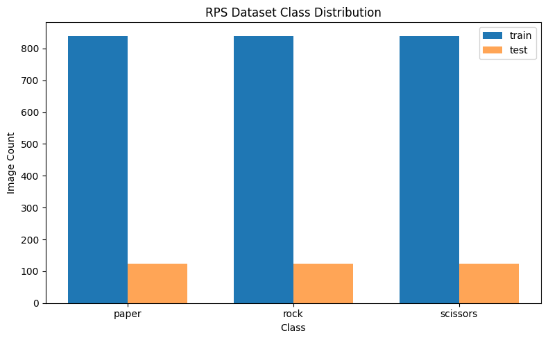

```python
import matplotlib.pyplot as plt
import numpy as np

labels_for_plot = sorted(train_counts)
x = np.arange(len(labels_for_plot))
width = 0.36
plt.figure(figsize=(8, 5))
plt.bar(x - width / 2, [train_counts[name] for name in labels_for_plot], width, label="train")
plt.bar(x + width / 2, [test_counts[name] for name in labels_for_plot], width, label="test", alpha=0.7)
plt.title("RPS Dataset Class Distribution")
plt.xlabel("Class")
plt.ylabel("Image Count")
plt.xticks(x, labels_for_plot)
plt.legend()
plt.tight_layout()
plt.savefig(OUTPUTS_DIR / "class_distribution.png", dpi=150)
plt.show()
```

## 5. 数据集图片预览

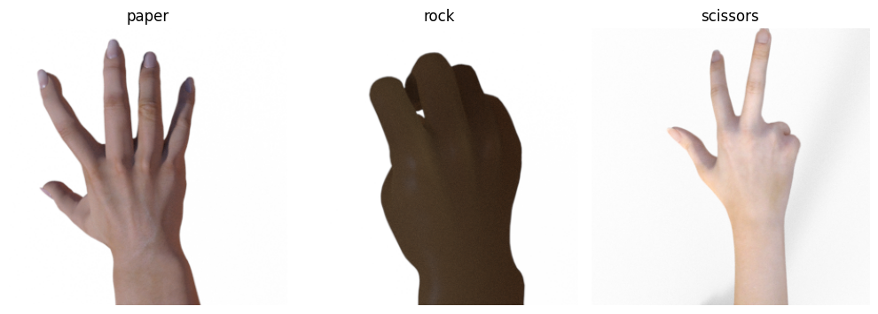

```python
import random
from PIL import Image

random.seed(123)
sample_paths = []
for class_name in sorted(train_counts):
    paths = sorted((train_extract_dir / class_name).glob("*"))
    sample_paths.append(random.choice(paths))

plt.figure(figsize=(10, 4))
for i, path in enumerate(sample_paths):
    img = Image.open(path).convert("RGB")
    plt.subplot(1, len(sample_paths), i + 1)
    plt.imshow(img)
    plt.title(path.parent.name)
    plt.axis("off")
plt.tight_layout()
plt.savefig(OUTPUTS_DIR / "dataset_preview.png", dpi=150)
plt.show()
```

## 6. 图片预处理与数据生成器

```python
from tensorflow.keras.preprocessing.image import ImageDataGenerator

IMG_SIZE = (150, 150)
BATCH_SIZE = 32
SEED = 123

train_datagen = ImageDataGenerator(
    rescale=1.0 / 255,
    validation_split=0.2,
    rotation_range=20,
    width_shift_range=0.1,
    height_shift_range=0.1,
    zoom_range=0.1,
    horizontal_flip=True,
)
test_datagen = ImageDataGenerator(rescale=1.0 / 255)

train_generator = train_datagen.flow_from_directory(
    train_extract_dir,
    target_size=IMG_SIZE,
    batch_size=BATCH_SIZE,
    class_mode="categorical",
    subset="training",
    seed=SEED,
)
validation_generator = train_datagen.flow_from_directory(
    train_extract_dir,
    target_size=IMG_SIZE,
    batch_size=BATCH_SIZE,
    class_mode="categorical",
    subset="validation",
    seed=SEED,
)
test_generator = test_datagen.flow_from_directory(
    test_extract_dir,
    target_size=IMG_SIZE,
    batch_size=BATCH_SIZE,
    class_mode="categorical",
    shuffle=False,
)

class_indices = train_generator.class_indices
index_to_class = {v: k for k, v in class_indices.items()}
class_names = [index_to_class[i] for i in range(len(index_to_class))]
(MODELS_DIR / "labels.txt").write_text("\n".join(class_names) + "\n", encoding="utf-8")
print("class_indices:", class_indices)
print("Class names in model output order:", class_names)
```

```
Found 2016 images belonging to 3 classes.
```

```
Found 504 images belonging to 3 classes.
```

```
Found 372 images belonging to 3 classes.
```

```
class_indices: {'paper': 0, 'rock': 1, 'scissors': 2}
Class names in model output order: ['paper', 'rock', 'scissors']
```

## 7. 定义 Sequential CNN 模型

```python
from tensorflow.keras import layers, models

preview_model = models.Sequential(
    [
        layers.InputLayer(input_shape=(150, 150, 3), name="input_image"),
        layers.Conv2D(32, (3, 3), activation="relu", name="conv2d_1"),
        layers.MaxPooling2D(2, 2, name="maxpool_1"),
        layers.Conv2D(64, (3, 3), activation="relu", name="conv2d_2"),
        layers.MaxPooling2D(2, 2, name="maxpool_2"),
        layers.Conv2D(128, (3, 3), activation="relu", name="conv2d_3"),
        layers.MaxPooling2D(2, 2, name="maxpool_3"),
        layers.Conv2D(128, (3, 3), activation="relu", name="conv2d_4"),
        layers.MaxPooling2D(2, 2, name="maxpool_4"),
        layers.Flatten(name="flatten"),
        layers.Dropout(0.5, name="dropout"),
        layers.Dense(256, activation="relu", name="dense_1"),
        layers.Dense(3, activation="softmax", name="predictions"),
    ],
    name="rps_sequential_cnn",
)
preview_model.summary()
```

```
Model: "rps_sequential_cnn"
```

```
_________________________________________________________________
```

```
 Layer (type)                Output Shape              Param #
```

```
 conv2d_1 (Conv2D)           (None, 148, 148, 32)      896
```

```
 maxpool_1 (MaxPooling2D)    (None, 74, 74, 32)        0
```

```
 conv2d_2 (Conv2D)           (None, 72, 72, 64)        18496
```

```
 maxpool_2 (MaxPooling2D)    (None, 36, 36, 64)        0
```

```
 conv2d_3 (Conv2D)           (None, 34, 34, 128)       73856
```

```
 maxpool_3 (MaxPooling2D)    (None, 17, 17, 128)       0
```

```
 conv2d_4 (Conv2D)           (None, 15, 15, 128)       147584
```

```
 maxpool_4 (MaxPooling2D)    (None, 7, 7, 128)         0
```

```
 flatten (Flatten)           (None, 6272)              0
```

```
 dropout (Dropout)           (None, 6272)              0
```

```
 dense_1 (Dense)             (None, 256)               1605888
```

```
 predictions (Dense)         (None, 3)                 771
```

```
Total params: 1,847,491
```

```
Trainable params: 1,847,491
```

```
Non-trainable params: 0
```

```
_________________________________________________________________
```

## 8. 编译模型 compile

`compile` 用于告诉模型如何学习。`optimizer` 表示如何调整参数，`loss` 表示模型错得有多严重，`accuracy` 表示分类正确率。

```python
preview_model.compile(
    optimizer="adam",
    loss="categorical_crossentropy",
    metrics=["accuracy"],
)
print("Model compiled with optimizer=adam, loss=categorical_crossentropy, metrics=accuracy")
```

```
Model compiled with optimizer=adam, loss=categorical_crossentropy, metrics=accuracy
```

## 9. 训练模型 fit、评估、保存和 TFLite 转换

下面调用 `src/train_rps_model.py` 中的完整训练流程。该流程会真实执行 `history = model.fit(...)`，并保存 Keras 模型、SavedModel、普通 TFLite、量化 TFLite、accuracy / loss 曲线、混淆矩阵和样例推理结果。为保证本地课堂实验效率，本次执行 5 个 epoch。

```python
import json
from train_rps_model import run_training

metrics = run_training(epochs=5)
metrics
```

```
Found 2016 images belonging to 3 classes.
```

```
Found 504 images belonging to 3 classes.
```

```
Found 372 images belonging to 3 classes.
```

```
63/63 - 59s - loss: 0.8750 - accuracy: 0.5833 - val_loss: 0.9285 - val_accuracy: 0.5000 - 59s/epoch - 937ms/step
```

```
63/63 - 37s - loss: 0.3492 - accuracy: 0.8720 - val_loss: 0.5349 - val_accuracy: 0.7321 - 37s/epoch - 590ms/step
```

```
63/63 - 39s - loss: 0.1199 - accuracy: 0.9554 - val_loss: 0.3538 - val_accuracy: 0.8631 - 39s/epoch - 620ms/step
```

```
63/63 - 37s - loss: 0.0850 - accuracy: 0.9727 - val_loss: 0.1630 - val_accuracy: 0.9385 - 37s/epoch - 592ms/step
```

```
63/63 - 38s - loss: 0.1019 - accuracy: 0.9673 - val_loss: 0.2308 - val_accuracy: 0.9425 - 38s/epoch - 600ms/step
```

```
WARNING:absl:Found untraced functions such as _jit_compiled_convolution_op, _jit_compiled_convolution_op, _jit_compiled_convolution_op, _jit_compiled_convolution_op while saving (showing 4 of 4). These functions will not be directly callable after loading.
```

```
INFO:tensorflow:Assets written to: H:\福建师范大学\大三下\软件实践研发（3）\E5_2_RPS_Gesture_Model_Generation\models\saved_model\assets
```

```
INFO:tensorflow:Assets written to: H:\福建师范大学\大三下\软件实践研发（3）\E5_2_RPS_Gesture_Model_Generation\models\saved_model\assets
```

```
{'test_loss': 0.019105214625597,
 'test_accuracy': 1.0,
 'class_indices': {'paper': 0, 'rock': 1, 'scissors': 2},
 'class_names': ['paper', 'rock', 'scissors'],
 'image_size': [150, 150],
 'batch_size': 32,
 'epochs': 5,
 'train_counts': {'paper': 840, 'rock': 840, 'scissors': 840},
 'test_counts': {'paper': 124, 'rock': 124, 'scissors': 124},
 'python_version': '3.10.2',
 'tensorflow_version': '2.10.1',
 'numpy_version': '1.23.5',
 'matplotlib_version': '3.10.9',
 'pandas_version': '2.3.3',
 'gpu_devices': [],
 'training_device': 'local Windows CPU',
 'training_seconds': 211.15,
 'final_train_accuracy': 0.9672619104385376,
 'final_val_accuracy': 0.942460298538208,
 'final_train_loss': 0.10186504572629929,
 'final_val_loss': 0.2308243364095688}
```

## 10. 查看准确率 / 损失曲线、混淆矩阵和样例预测

```
H:\福建师范大学\大三下\软件实践研发（3）\E5_2_RPS_Gesture_Model_Generation\outputs\training_accuracy_loss.png exists= True
```

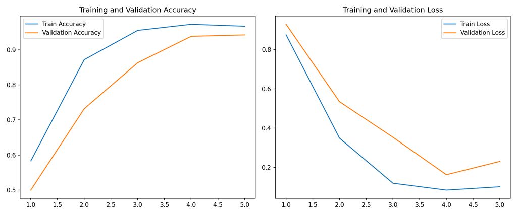

```
H:\福建师范大学\大三下\软件实践研发（3）\E5_2_RPS_Gesture_Model_Generation\outputs\confusion_matrix.png exists= True
```

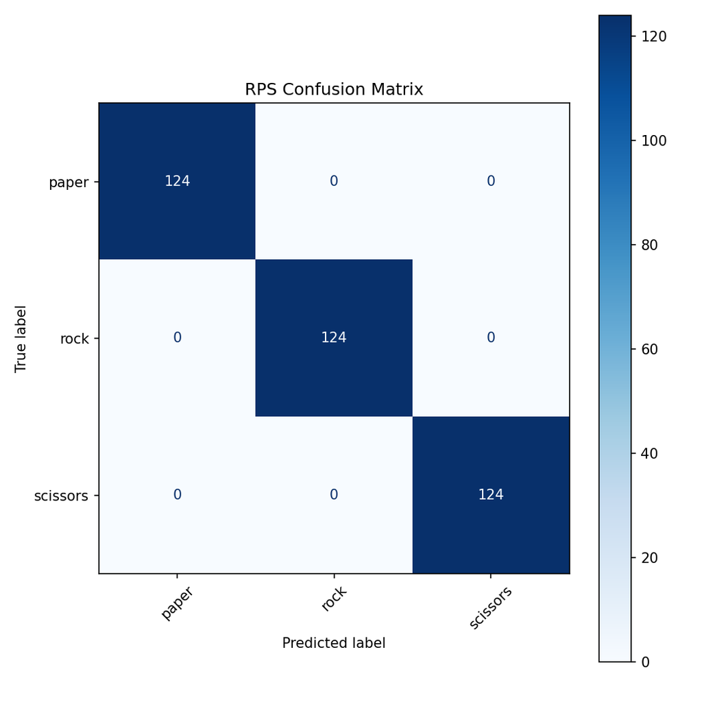

```
H:\福建师范大学\大三下\软件实践研发（3）\E5_2_RPS_Gesture_Model_Generation\outputs\sample_predictions_keras.png exists= True
```

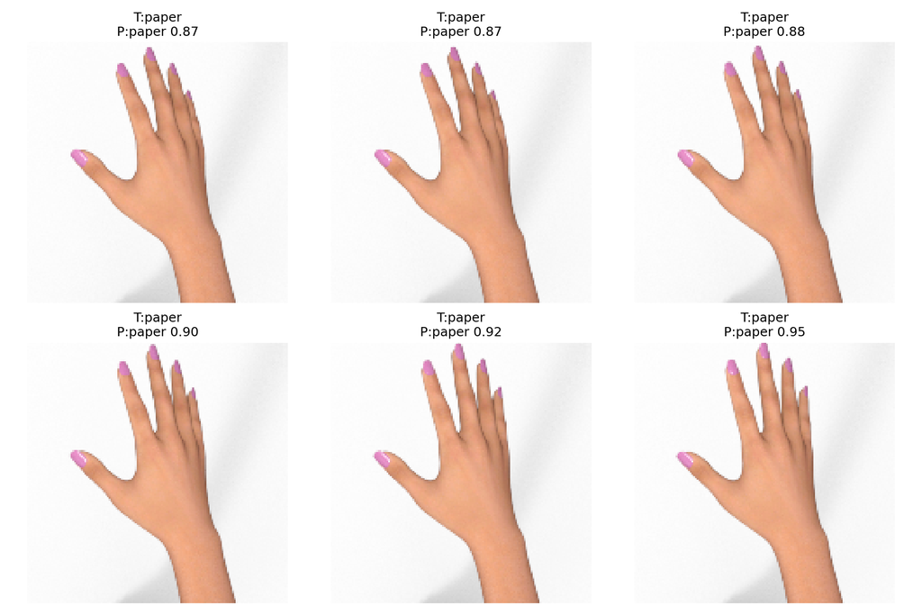

```
H:\福建师范大学\大三下\软件实践研发（3）\E5_2_RPS_Gesture_Model_Generation\outputs\sample_predictions_tflite.png exists= True
```

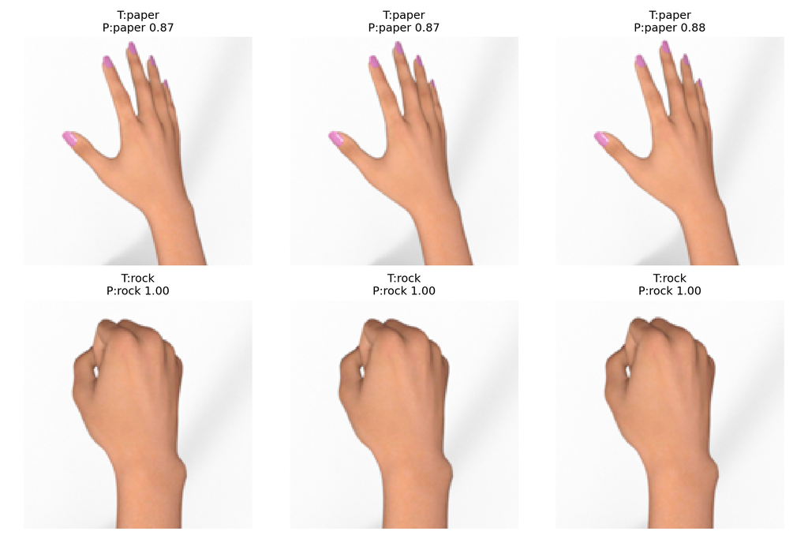

```python
from IPython.display import Image as DisplayImage, display

for image_name in [
    "training_accuracy_loss.png",
    "confusion_matrix.png",
    "sample_predictions_keras.png",
    "sample_predictions_tflite.png",
]:
    path = OUTPUTS_DIR / image_name
    print(path, "exists=", path.exists())
    if path.exists():
        display(DisplayImage(filename=str(path)))
```

## 11. 测试集评估指标

```python
import json

metrics_path = OUTPUTS_DIR / "evaluation_metrics.json"
metrics = json.loads(metrics_path.read_text(encoding="utf-8"))
metrics
```

```
{'test_loss': 0.019105214625597,
 'test_accuracy': 1.0,
 'class_indices': {'paper': 0, 'rock': 1, 'scissors': 2},
 'class_names': ['paper', 'rock', 'scissors'],
 'image_size': [150, 150],
 'batch_size': 32,
 'epochs': 5,
 'train_counts': {'paper': 840, 'rock': 840, 'scissors': 840},
 'test_counts': {'paper': 124, 'rock': 124, 'scissors': 124},
 'python_version': '3.10.2',
 'tensorflow_version': '2.10.1',
 'numpy_version': '1.23.5',
 'matplotlib_version': '3.10.9',
 'pandas_version': '2.3.3',
 'gpu_devices': [],
 'training_device': 'local Windows CPU',
 'training_seconds': 211.15,
 'final_train_accuracy': 0.9672619104385376,
 'final_val_accuracy': 0.942460298538208,
 'final_train_loss': 0.10186504572629929,
 'final_val_loss': 0.2308243364095688}
```

## 12. Python 端 TFLite 推理验证

```python
import subprocess

subprocess.run([sys.executable, str(SRC_DIR / "test_tflite_inference.py")], check=True)
print((OUTPUTS_DIR / "tflite_inference_results.csv").read_text(encoding="utf-8").splitlines()[:10])
```

[output not shown]

## 13. 模型文件检查

```python
for path in sorted(MODELS_DIR.rglob("*")):
    if path.is_file():
        print(f"{path.relative_to(PROJECT_ROOT)} - {path.stat().st_size} bytes")
```

```
models\labels.txt - 23 bytes
models\model_info.md - 1531 bytes
models\rps_classifier.keras - 22232808 bytes
models\rps_classifier.tflite - 7395104 bytes
models\rps_classifier_quant.tflite - 1863344 bytes
models\saved_model\keras_metadata.pb - 24705 bytes
models\saved_model\saved_model.pb - 202502 bytes
models\saved_model\variables\variables.data-00000-of-00001 - 22183434 bytes
models\saved_model\variables\variables.index - 3178 bytes
```

## 14. 实验总结

本实验完成了 TensorFlow 石头剪刀布手势识别模型生成。实验从数据集下载开始，完成了图片预处理、Sequential CNN 模型构建、`compile` 编译、`fit` 训练、测试集评估和性能图形绘制。通过 accuracy / loss 曲线、混淆矩阵和样例预测图，可以直观看到模型对 `rock`、`paper`、`scissors` 三类手势的识别效果。

本实验还将 Keras 模型转换为 TFLite / LiteRT 模型，并使用 Python 端 TFLite Interpreter 验证推理结果，为后续在 Android 端接入手势识别模型打下基础。